[figure not shown]

#### Linguagens de Programação para Ciência de Dados

# Recursos básicos de visualização do R

Prof. Walmes M. Zeviani

2018-04-14

# 1 Os recusos para visualização

O [landscape de recursos para visualização](https://www.stat.ubc.ca/~jenny/STAT545A/block90_baseLatticeGgplot2.html) de dados no R pode ser representado por uma divisão em 3 territórios.

- `graphics`: representa o pacote básico `graphics` e vários pacotes que complementam funcionalidades dele, como o [`plotrix`](https://cran.r-project.org/package=plotrix) e [`gplots`](https://cran.r-project.org/package=gplots). Contém os recursos mais primitivos, com funções de alto e baixo nível na sua maioria nativas nos pacotes básicos do R. Oferece muitos recursos para confecção de gráficos porém não tem suporte nativo para acomodar informação adicional como cores, linhas, pontos, preenchimentos de acordo com variáveis categóricas. Ainda assim, é o que mais se usa para implementar gráficos de diagnóstico de modelos e visualização que envolva até um par de variáveis. É importante saber utilizar a `graphics` para customização de gráficos resultados de análise de dados (dendrogramas, biplots, gráficos de resíduos, quantil-quantil, etc).
- [`lattice`](http://lattice.r-forge.r-project.org/): desenvolvido por [Deepayan Sarkar](https://www.isid.ac.in/~deepayan/) com primeira alternativa aos recursos básicos. O principais recursos foram a plotagem multi-painel e mapeamento de informação adicional usando cores, símbolos, preenchimentos, espessura, etc. A [`lattice`](http://lattice.r-forge.r-project.org/) faz parte do grupo de pacotes recomendados do R, portanto, já vem com a instalação básica. Tem sido utilizado por muitos pacotes, como a `nlme` e `lme4` para apresentar resultados de análises. O pacote [`latticeExtra`](http://latticeextra.r-forge.r-project.org/) estende as funcionalidades da [`lattice`](http://lattice.r-forge.r-project.org/). A importância da [`lattice`](http://lattice.r-forge.r-project.org/) está em pertencer ao grupo de pacotes recomendados, o que encoraja seu uso dentro de pacotes contribuidos, é rápida na confeção dos gráficos e possui recursos para ajuste fino da aparência do gráfico.
- [`ggplot2`](http://ggplot2.org/): desenvolvido por [Hadley Wickham](http://hadley.nz/), surgiu depois da [`lattice`](http://lattice.r-forge.r-project.org/) e é baseado na [*Grammar of Graphics*](http://byrneslab.net/classes/biol607/readings/wickham_layered-grammar.pdf), um modelo que permite a descrição concisa dos componentes de um gráfico. A [`ggplot2`](http://ggplot2.org/) possui a maioria dos recursos da [`lattice`](http://lattice.r-forge.r-project.org/), como condicionamento multi-painel, mas é melhor para o mapeamento de variáveis em atributos estéticos (símbolos, cores, etc). A customização dos gráficos é mais fatorável pois usa camadas para os diversos elementos gráficos. A importância da [`ggplot2`](http://ggplot2.org/) está no modelo mental mais claro, o tem contribuido para o ganho em popularidade. A [`ggplot2`](http://ggplot2.org/) é bem mais lenta para construir os gráficos que a [`lattice`](http://lattice.r-forge.r-project.org/) mas também é altamente customizável.

Para mais detalhes sobre os recursos gráficos, siga esse link: https://www.stat.ubc.ca/~jenny/STAT545A/block90_baseLatticeGgplot2.html.

Para uma descrição completada comparação entre [`lattice`](http://lattice.r-forge.r-project.org/) e [`ggplot2`](http://ggplot2.org/), siga esse link: https://learnr.wordpress.com/2009/08/26/ggplot2-version-of-figures-in-lattice-multivariate-data-visualization-with-r-final-part/

Confira no [R Graph Gallery](https://www.r-graph-gallery.com/) a variedade de gráficos confeccionados com o R.

Além dos recursos disponíveis nos territórios supradescritos, pode-se considerar ainda a existência de mais dois conjuntos de recursos: para mapas e gráficos interativos.

A visualização de dados geográficos conta com um vários pacotes específicos. Siga os links abaixo para ter uma ideia das funcionalidades:

- https://cran.r-project.org/web/views/Spatial.html;
- https://bhaskarvk.github.io/user2017.geodataviz/;
- http://spatial.ly/r/;
- https://data.cdrc.ac.uk/tutorial/an-introduction-to-spatial-data-analysis-and-visualisation-in-r;

Os recursos para visualização interativa de dados estão distribuídos em vários pacotes. Talvez o mais interessante deles seja o [`plotly`](https://plot.ly/) que permite a criação de gráficos interativos a partir da [`ggplot2`](http://ggplot2.org/) além de possuir funções próprias. Veja em [`plotly-R`](https://plot.ly/r/) a galeria de gráficos.

A visualização interativa é voltada para exibicação na WEB. Alguns dos pacotes para isso são estes:

- [`plotly`](https://plot.ly/r/).
- [`highcharter`](http://jkunst.com/highcharter/).
- [`googleVis`](https://cran.r-project.org/web/packages/googleVis/vignettes/googleVis_examples.html).
- [`rCharts`](https://ramnathv.github.io/rCharts/).
- [`leaflet`](https://rstudio.github.io/leaflet/).
- [`iplots`](http://rosuda.org/software/iPlots/).
- [`rgl`](https://cran.r-project.org/web/packages/rgl/vignettes/rgl.html).
- [`animation`](https://yihui.name/animation/).

# 2 Leitura dos dados

Para explorar os recursos básicos de visualização, serão usados dados reais sobre a venda do modelo Renault Duster extraídos da WEB. Os dados estão disponíveis online em http://www.leg.ufpr.br/~walmes/data/duster_venda_260314.txt.

Os dados contém informações sobre o preço de venda (R$, `valor`) e distância percorrida (km, `km`) além de outras características descritoras do veículo, como ano de fabricação, cor, tipo de câmbio.

```r
#-----------------------------------------------------------------------
# Dados de carros Duster à venda no webmotors em 26/03/2014.

# Importa a tabela de dados da web.
url <- "http://www.leg.ufpr.br/~walmes/data/duster_venda_260314.txt"
dus <- read.table(file = url,
                  header = TRUE,
                  sep = "\t",
                  encoding = "utf-8")
str(dus)
# 'data.frame': 699 obs. of  10 variables:
#  $ modelo: Factor w/ 11 levels "RENAULT DUSTER 1.6 4X2 16V FLEX 4P MANUAL",..: 3 1 2 2 1 1 2 3 6 2 ...
#  $ cor   : Factor w/ 9 levels "Azul","Branco",..: 5 1 5 5 5 8 6 6 6 6 ...
#  $ km    : int  31442 40800 56000 NA 45000 50000 44000 30000 41000 55000 ...
#  $ ano   : Factor w/ 7 levels "2011/2011","2011/2012",..: 2 2 2 2 2 4 3 4 2 2 ...
#  $ valor : num  41990 42500 42900 42990 43800 ...
#  $ cambio: Factor w/ 2 levels "AUTOMÁTICO","MANUAL": 2 2 2 2 2 2 2 2 2 2 ...
#  $ poten : num  1.6 1.6 1.6 1.6 1.6 1.6 1.6 1.6 2 1.6 ...
#  $ trac  : Factor w/ 2 levels "4X2","4X4": 1 1 1 1 1 1 1 1 1 1 ...
#  $ cat   : Factor w/ 5 levels " "," DYNAMIQUE ",..: 3 1 2 2 1 1 2 3 2 2 ...
#  $ novo  : Factor w/ 2 levels "novo","usado": 2 2 2 2 2 2 2 2 2 2 ...

# Cria ano do veículo com extração regex.
dus$ano <- factor(gsub(x = as.character(dus$ano),
                       pattern = "/\\d{4}$",
                       replacement = ""))

# Quantidade de NA em cada coluna.
apply(dus, MARGIN = 2, FUN = function(x) sum(is.na(x)))
# modelo    cor     km    ano  valor cambio  poten   trac    cat   novo
#      0      0    132      0      0      0      0      0      0      0
```

A variável `km` apresentou mais de uma centena de valores ausentes. A tabela tem 3 variáveis numéricas (`km`, `valor`, `poten`), sendo as demais todas categóricas.

# 3 Gráficos para uma variável categórica

A análise exploratória de variáveis categóricas é praticamente baseada na distribuição das frequências. Por ser uma variável não numérica, não é possível calcular medidas descritivas numéricas de posição (como média, mediada) ou de dispersão (variância, amplitude). Dessa forma, esta-se confinado à visualizações que consideram as frequências.

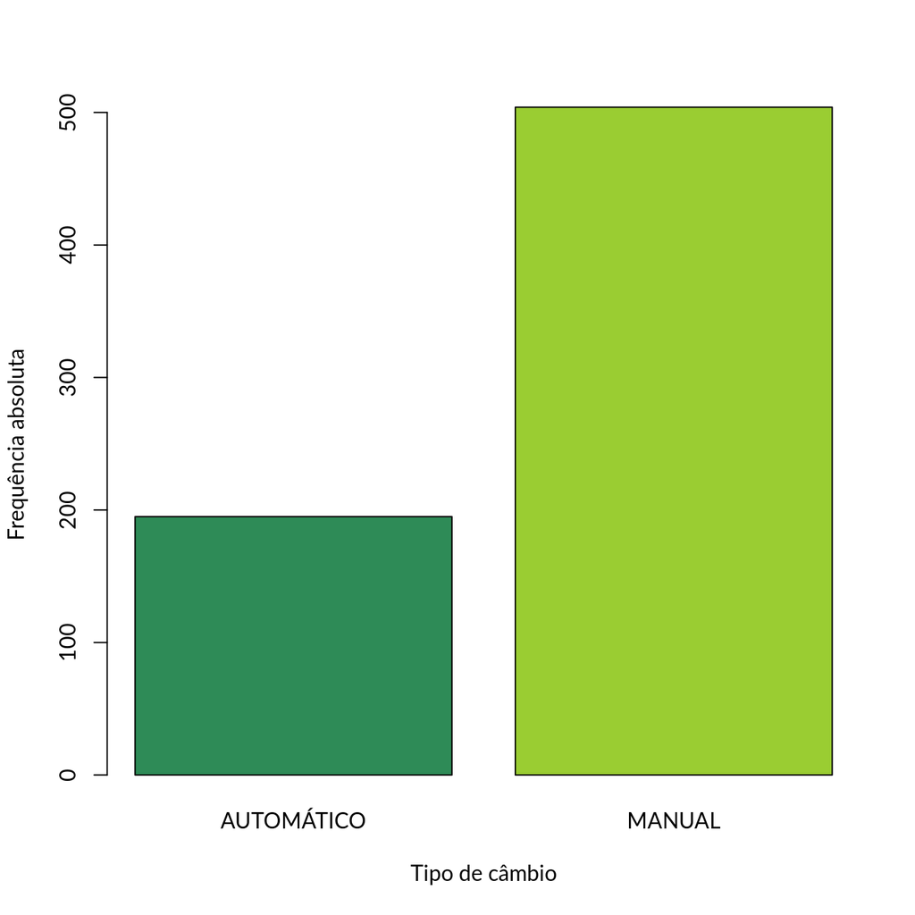

```r
#-----------------------------------------------------------------------
# Gráfico de barras e setores.

# Tabela de frequência.
x <- table(dus$cambio)
class(x)
# [1] "table"

# Se vem da xtabs() também tem classe `table`.
x <- xtabs(~cambio, data = dus)
class(x)
# [1] "xtabs" "table"

# Gráfico padrão.
# barplot(x)

# Com anotações nas margens e cores.
barplot(x,
        xlab = "Tipo de câmbio",
        ylab = "Frequência absoluta",
        col = c("seagreen", "yellowgreen"))
```

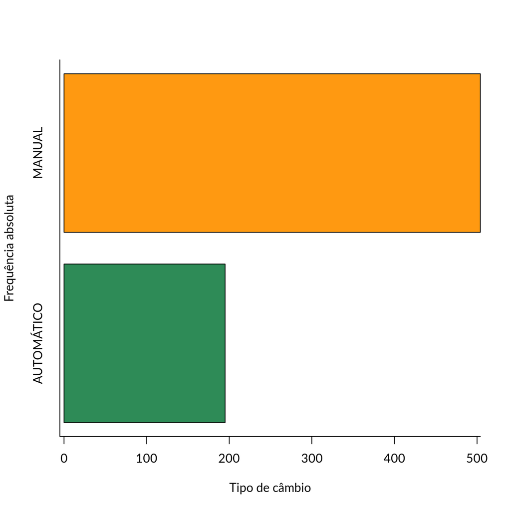

```r
# Horizontal.
barplot(x,
        horiz = TRUE,
        xlab = "Tipo de câmbio",
        ylab = "Frequência absoluta",
        col = c("seagreen", "#FF9911"))
box(bty = "L")
```

```r
# Cores com `green` no vetor de cores `colors()`.
grep(pattern = "green", x = colors(), value = TRUE)
#  [1] "darkgreen"         "darkolivegreen"    "darkolivegreen1"
#  [4] "darkolivegreen2"   "darkolivegreen3"   "darkolivegreen4"
#  [7] "darkseagreen"      "darkseagreen1"     "darkseagreen2"
# [10] "darkseagreen3"     "darkseagreen4"     "forestgreen"
# [13] "green"             "green1"            "green2"
# [16] "green3"            "green4"            "greenyellow"
# [19] "lawngreen"         "lightgreen"        "lightseagreen"
# [22] "limegreen"         "mediumseagreen"    "mediumspringgreen"
# [25] "palegreen"         "palegreen1"        "palegreen2"
# [28] "palegreen3"        "palegreen4"        "seagreen"
# [31] "seagreen1"         "seagreen2"         "seagreen3"
# [34] "seagreen4"         "springgreen"       "springgreen1"
# [37] "springgreen2"      "springgreen3"      "springgreen4"
# [40] "yellowgreen"
```

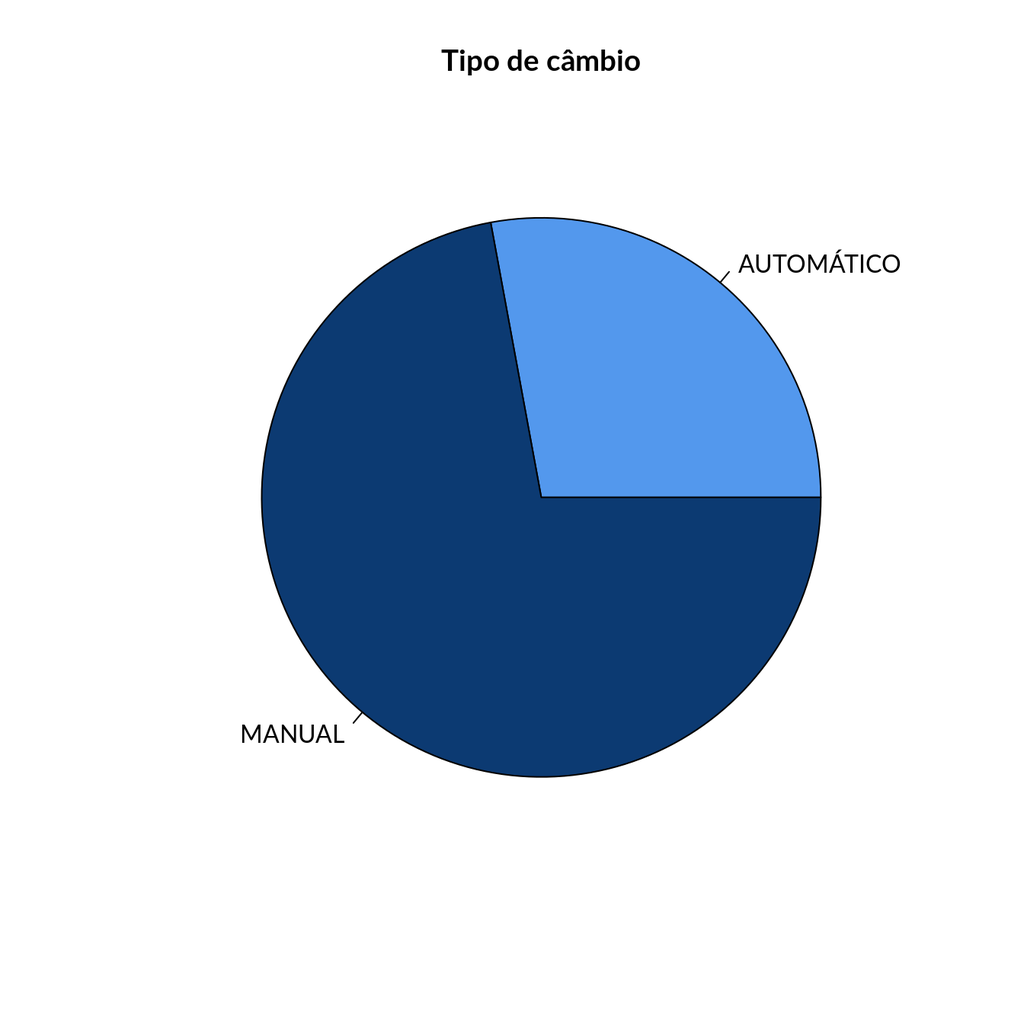

```r
# Gráfico de setores. Evite usar referências radiais pois comparações de
# arcos são prejudicadas por não estarem alinhadas.
pie(x,
    col = c("#5398ed",
            rgb(12, 58, 114, max = 255)),
    main = "Tipo de câmbio")
```

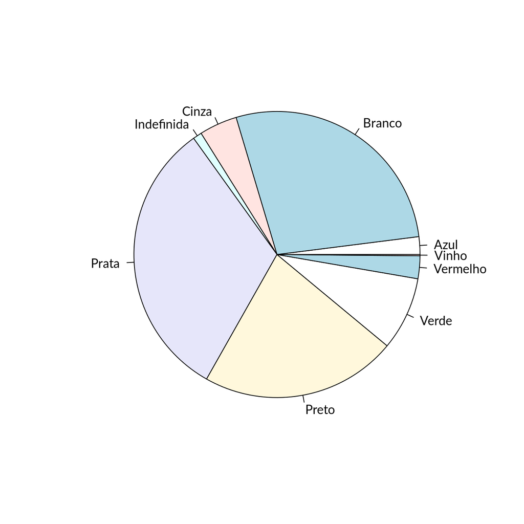

```r
# Para as cores do carro.
x <- xtabs(~cor, data = dus)
pie(x)
```

Tanto os gráficos de barras (vertical ou horizontal) quanto o de setores (pizza), representam a distribuição de frequência. No entanto, exceto por razões bem específicas, o gráfico de setores deve ser evitado. A percepção sobre do comprimento dos setores é comprometida pela ausência de um sistema de referência linear. Ou seja, o gráfico está em um sistema de referência polar que dificulta a percepção de comprimentos em arco.

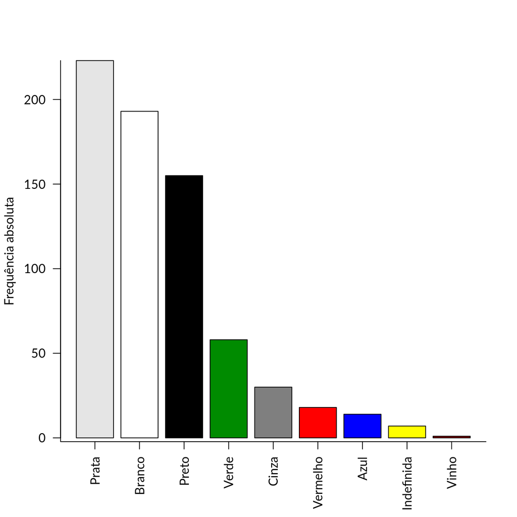

```r
# Vetor que cores para usar com cada cor de veiculo.
cols <- c("blue", "white", "gray50", "Yellow", "gray90", "black",
          "green4", "red", "red4")

cbind(levels(dus$cor), cols)
#                    cols
#  [1,] "Azul"       "blue"
#  [2,] "Branco"     "white"
#  [3,] "Cinza"      "gray50"
#  [4,] "Indefinida" "Yellow"
#  [5,] "Prata"      "gray90"
#  [6,] "Preto"      "black"
#  [7,] "Verde"      "green4"
#  [8,] "Vermelho"   "red"
#  [9,] "Vinho"      "red4"

# Reordenar os níveis do fator e as cores.
ord <- order(x, decreasing = TRUE)
cols <- cols[ord]
x <- x[ord]
n <- names(x)
dus$cor <- factor(dus$cor, levels = n)

cbind(levels(dus$cor), cols)
#                    cols
#  [1,] "Prata"      "gray90"
#  [2,] "Branco"     "white"
#  [3,] "Preto"      "black"
#  [4,] "Verde"      "green4"
#  [5,] "Cinza"      "gray50"
#  [6,] "Vermelho"   "red"
#  [7,] "Azul"       "blue"
#  [8,] "Indefinida" "Yellow"
#  [9,] "Vinho"      "red4"

a <- barplot(x,
             xaxt = "n",
             las = 1,
             col = cols)
mtext(side = 2, text = "Frequência absoluta", line = 3)
axis(side = 1, at = a, labels = n, las = 2)
box(bty = "L")
```

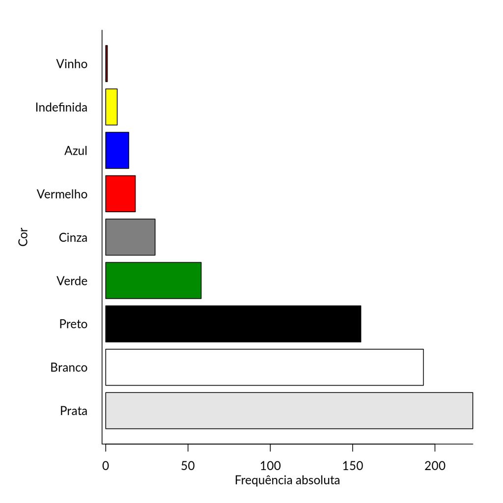

```r
par(mar = c(4.1, 7.1, 2.1, 2.1))
barplot(x,
        horiz = TRUE,
        las = 1,
        col = cols)
mtext(side = 2, text = "Cor", line = 5)
mtext(side = 1, text = "Frequência absoluta", line = 2)
box(bty = "L")
```

```r
# Fecha a janela gráfica para restaturar as configurações.
dev.off()
# null device
#           1
```

Quando o número de categorias cresce, a leitura do gráfico de barras é naturalmente mais demorada. Porém, se não existe uma ordenação natural nos níveis da variável categória (variável categórica nominal e não ordinal), a ordenação das barras com relação ao valor aprimora a visualização.

O uso das barras horizontais é recomendado quando os texto sob o eixo é comprido. O texto na vertical não favorece a rápida leitura, por isso colocá-lo na horizontal é uma boa opção.

# 4 Gráfico para duas variáveis categóricas

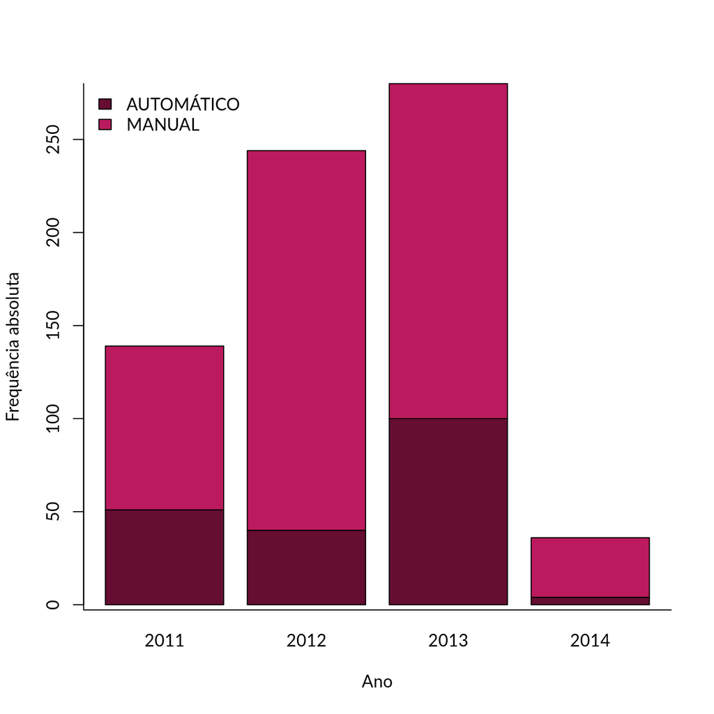

```r
#-----------------------------------------------------------------------
# Gráficos de barras emplilhadas (stacked) e lado a lado.

x <- xtabs(~cambio + ano, data = dus)
x
#             ano
# cambio       2011 2012 2013 2014
#   AUTOMÁTICO   51   40  100    4
#   MANUAL       88  204  180   32

cols <- c("#660d32", "#bc1a5e")

# Barras empilhadas.
barplot(x,
        beside = FALSE,
        xlab = "Ano",
        ylab = "Frequência absoluta",
        col = cols)
legend("topleft",
       legend = levels(dus$cambio),
       fill = cols,
       bty = "n")
box(bty = "L")
```

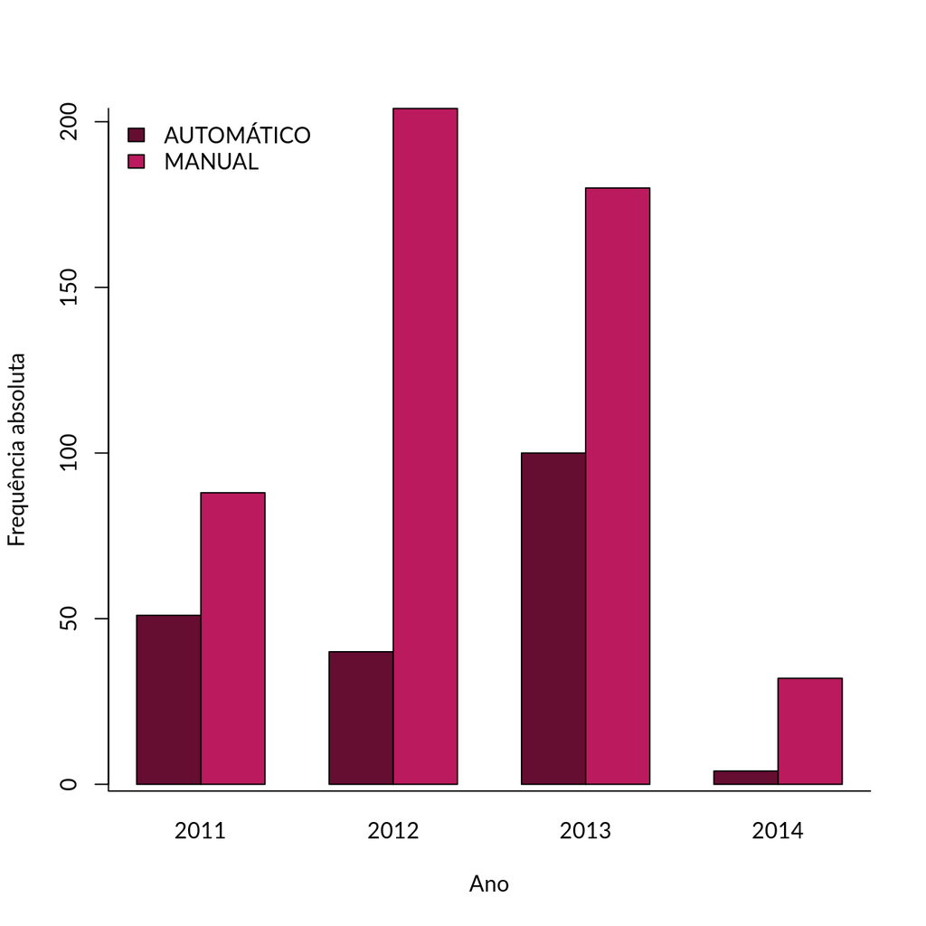

```r
# Barras lado a lado.
barplot(x,
        beside = TRUE,
        xlab = "Ano",
        ylab = "Frequência absoluta",
        col = cols)
legend("topleft",
       legend = levels(dus$cambio),
       fill = cols,
       bty = "n")
box(bty = "L")
```

Quando duas ou variáveis categóricas são consideradas, pode-se representar a distribuição de frequência com barras empilhadas ou barras lado a lado. O enfoque desses gráficos é diferente.

**Barras empilhadas**

1. Principal: ver os totais absolutos marginais de cada ano.
2. Secundário: ver as proporções de cada câmbio em cada ano.
3. Ruim: compreender a série de frequências absolutas de cada câmbio ao longo dos anos.

**Barras lado a lado**

1. Principal: comparar os valores absolutos dos câmbios em cada ano.
2. Secundário: entender a série de cada câmbio ao longo dos anos.
3. Ruim: compreender a série do total absoluto ao longo dos anos.
4. Ruim: determinar a proporção de cada câmbio em cada ano.

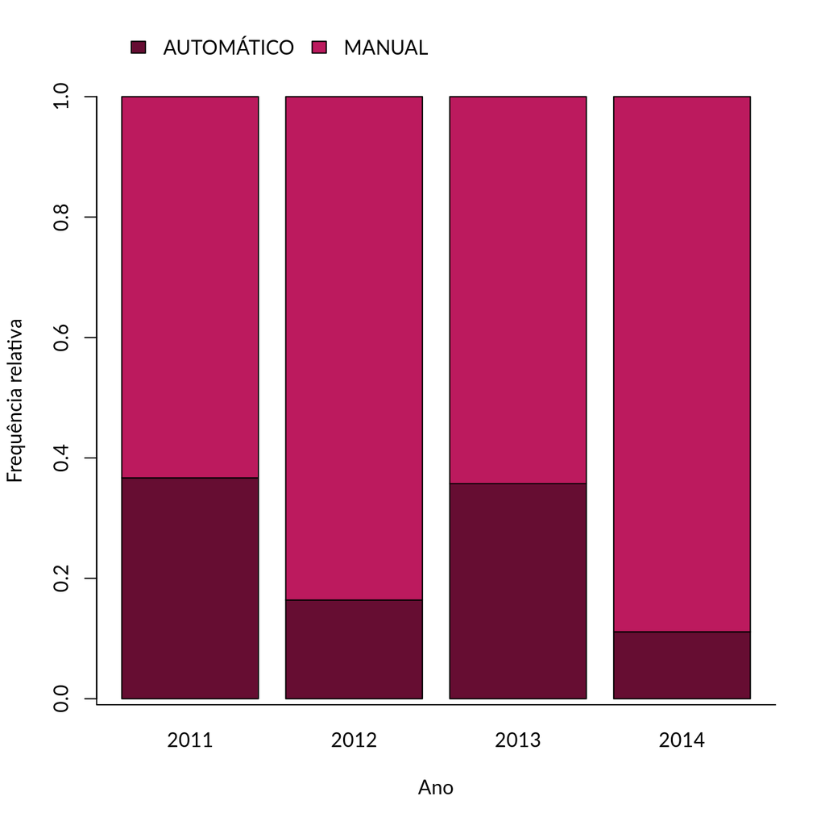

```r
x
#             ano
# cambio       2011 2012 2013 2014
#   AUTOMÁTICO   51   40  100    4
#   MANUAL       88  204  180   32

u <- x %*% diag(1/colSums(x))
colnames(u) <- colnames(x)
u
#
# cambio            2011      2012      2013      2014
#   AUTOMÁTICO 0.3669065 0.1639344 0.3571429 0.1111111
#   MANUAL     0.6330935 0.8360656 0.6428571 0.8888889

# Barras empilhadas relativas.
barplot(u,
        beside = FALSE,
        xlab = "Ano",
        ylab = "Frequência relativa",
        col = cols)
legend("topleft",
       inset = c(0.025, -0.12),
       xpd = TRUE,
       ncol = 2,
       legend = levels(dus$cambio),
       fill = cols,
       bty = "n")
box(bty = "L")
```

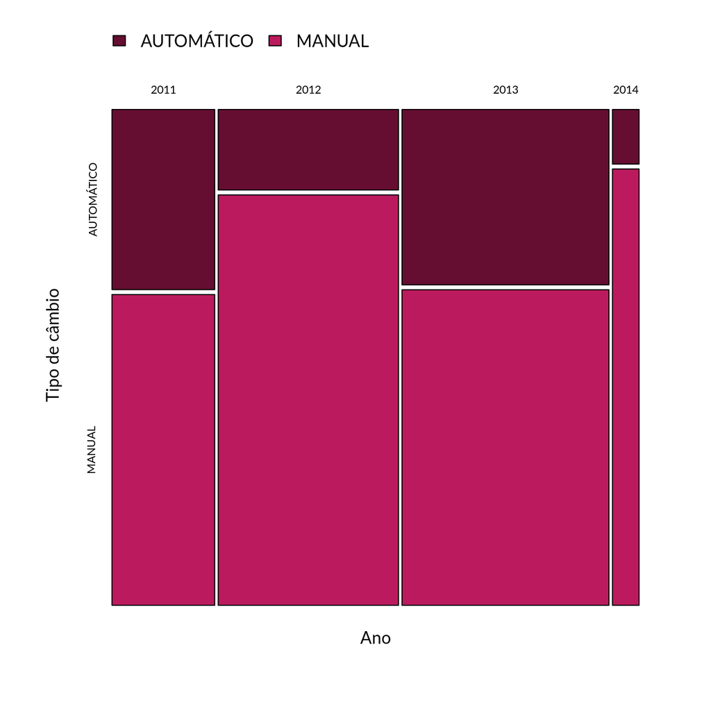

```r
mosaicplot(t(x),
           off = c(2, 1),
           col = cols,
           ylab = "Tipo de câmbio",
           xlab = "Ano",
           main = NULL)
legend("topleft",
       inset = c(0.025, -0.12),
       xpd = TRUE,
       ncol = 2,
       legend = levels(dus$cambio),
       fill = cols,
       bty = "n")
```

**Barras empilhadas padronizadas**

As barras empilhadas podem ter comprimento padronizado para representar a frequência relativa. Dessa forma é mais facil comprar as frquências relativas. Nesse gráfico as ênfases são:

1. Principal: comprar as proporções dos câmbios em cada ano independente dos totais absolutos.
2. Ruim: determinar os totais relativos de cada ano.
3. Ruim: determinar os totais absolutos dos anos e câmbios.

**Gráfico de barras como mosaico**

Mais um tipo de gráfico interessante é o mosaico. Ele é uma exibição das frequências relativas marginais e condicionais. Tem por objetivo:

1. Principal: ver os totais dos anos (largura).
2. Secundário: ver as proporções de cada câmbio em cada ano (alturas relativas).
3. Ruim: determinar os valores absolutos.

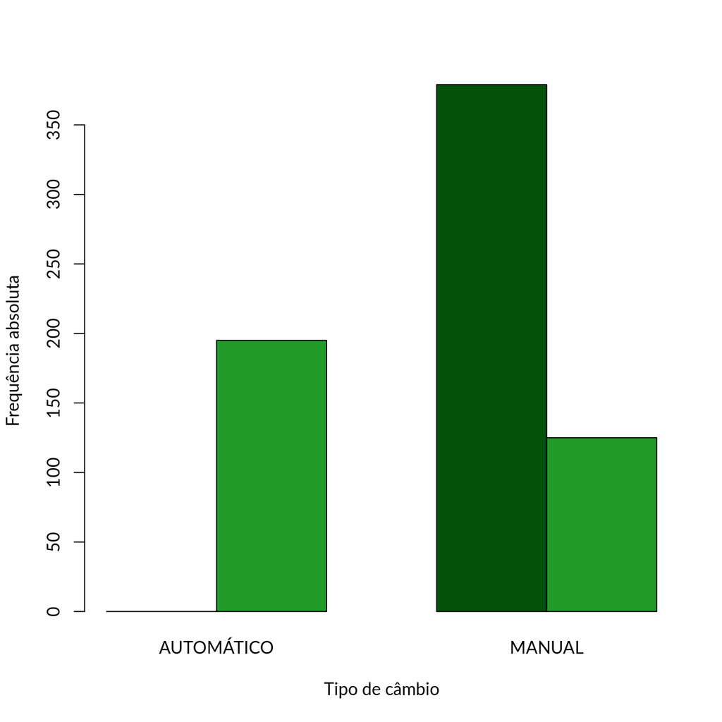

```r
#-----------------------------------------------------------------------
# Anotações nas barras.

x <- xtabs(~cambio + poten, data = dus)
x
#             poten
# cambio       1.6   2
#   AUTOMÁTICO   0 195
#   MANUAL     379 125

# Cores de preenchimento para as barras.
cols <- c("#04510a", "#229b2b")

# Barras lado a lado.
bp <- barplot(t(x),
              beside = TRUE,
              col = cols,
              xlab = "Tipo de câmbio",
              ylab = "Frequência absoluta")
```

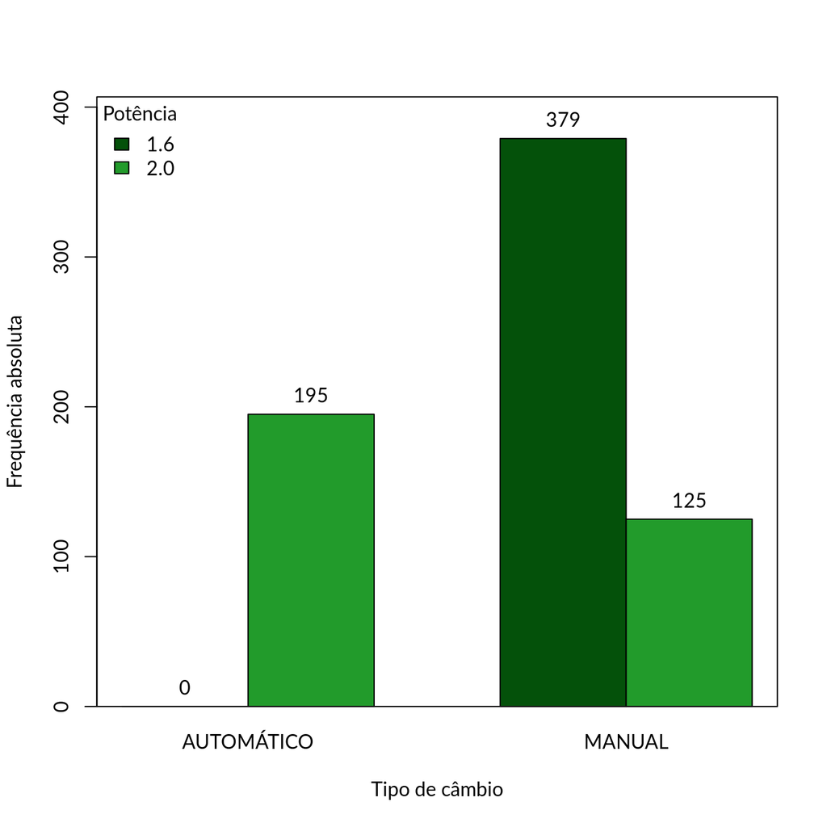

```r
bp
#      [,1] [,2]
# [1,]  1.5  4.5
# [2,]  2.5  5.5

# Calcula a altura de uma palavra em termos da escala y do gráfico.
sh <- strheight("um texto qualquer")
sh
# [1] 9.273014

# Opera com os limites do gráfico armazenados em `par()$usr`.
lim <- par()$usr[4] + 3 * sh

# Refaz o gráfico com espaço para o texto.
barplot(t(x),
        beside = TRUE,
        col = cols,
        ylim = c(0, lim),
        xlab = "Tipo de câmbio",
        ylab = "Frequência absoluta")
legend("topleft",
       title = "Potência",
       legend = c("1.6","2.0"),
       fill = cols,
       bty = "n")
text(x = c(bp),
     y = t(x),
     labels = t(x),
     pos = 3)
box()
```

Se mais variáveis forem envolvidas, o gráfico de mosaico fará a representação com mais divisões nos retângulos.

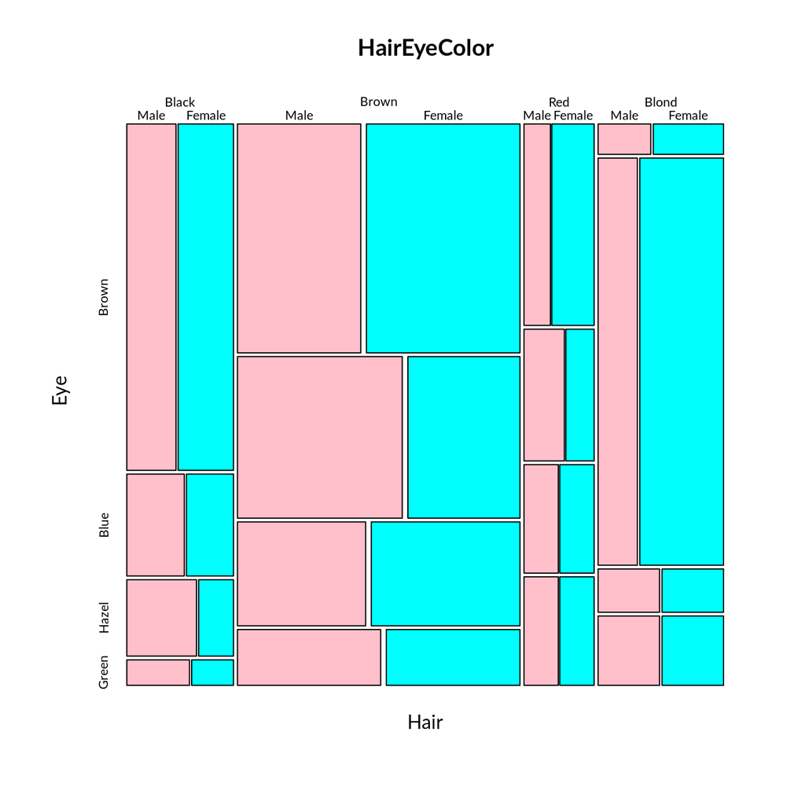

```r
# Mais dimensões.
mosaicplot(HairEyeColor,
           off = 2,
           col = c("pink", "cyan"))
```

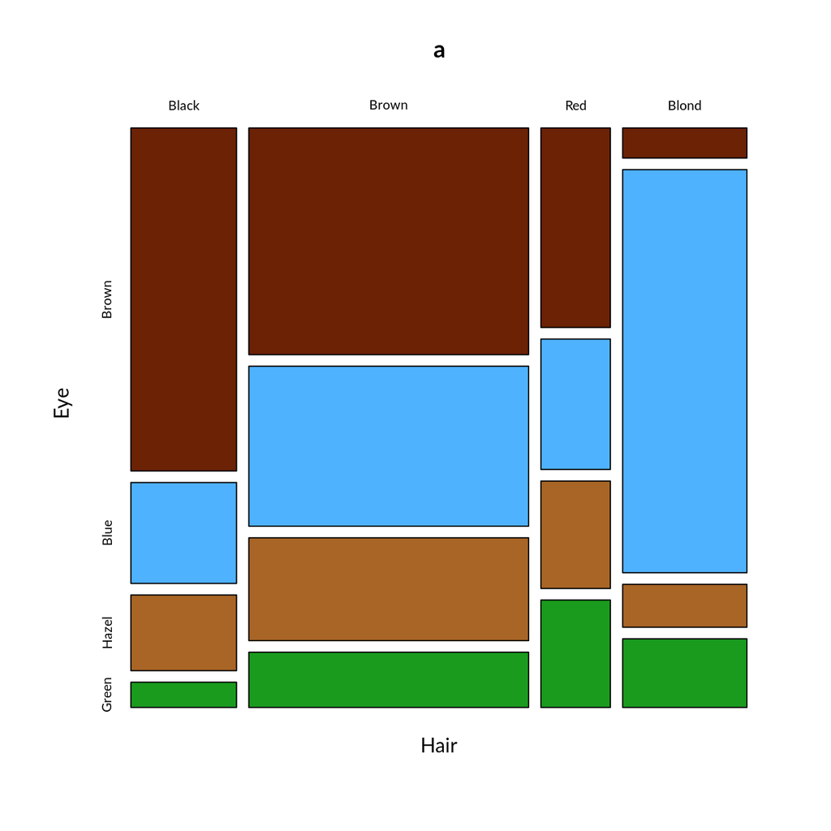

```r
# Obtendo totais para fazer gráficos de barras.
dimnames(HairEyeColor)
# $Hair
# [1] "Black" "Brown" "Red"   "Blond"
#
# $Eye
# [1] "Brown" "Blue"  "Hazel" "Green"
#
# $Sex
# [1] "Male"   "Female"
a <- apply(HairEyeColor,
           MARGIN = c(1, 2),
           FUN = sum)

# Vetor que associa cores conforme os níveis dos fatores às cores usadas
# para preenchimento.
cols <- c(Brown = "#6b2205",
          Blue = "#4fb2ff",
          Green = "#1a9b1e",
          Blond = "#d8d652",
          Red = "#bc1405",
          Black = "#210a08",
          Hazel = "#a86526")

# Mosaico.
mosaicplot(a,
           col = cols[colnames(a)])
```

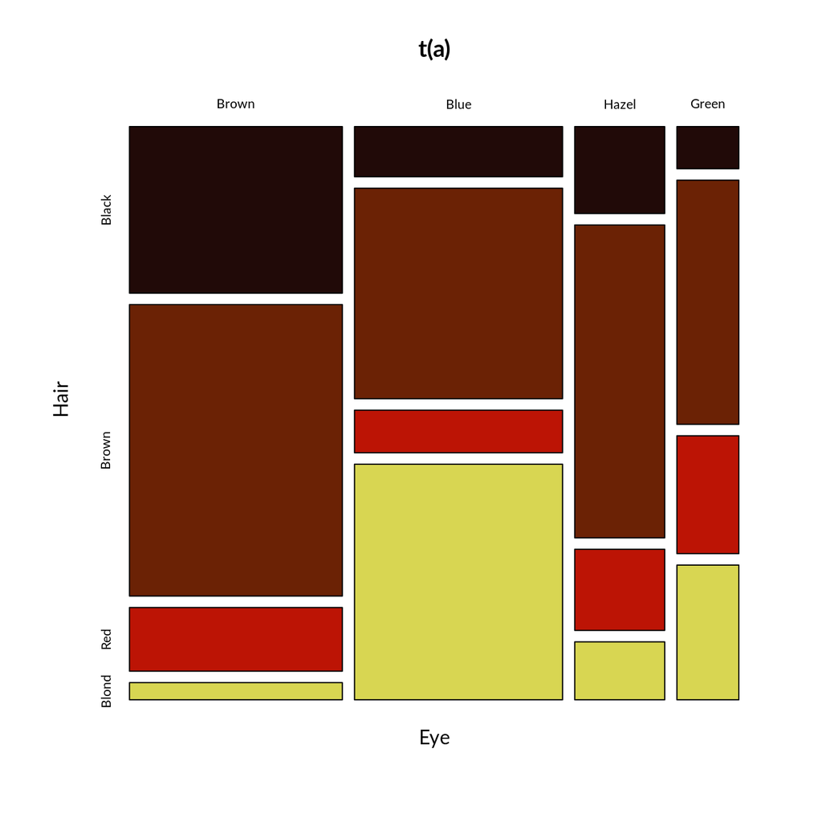

```r
mosaicplot(t(a),
           col = cols[rownames(a)])
```

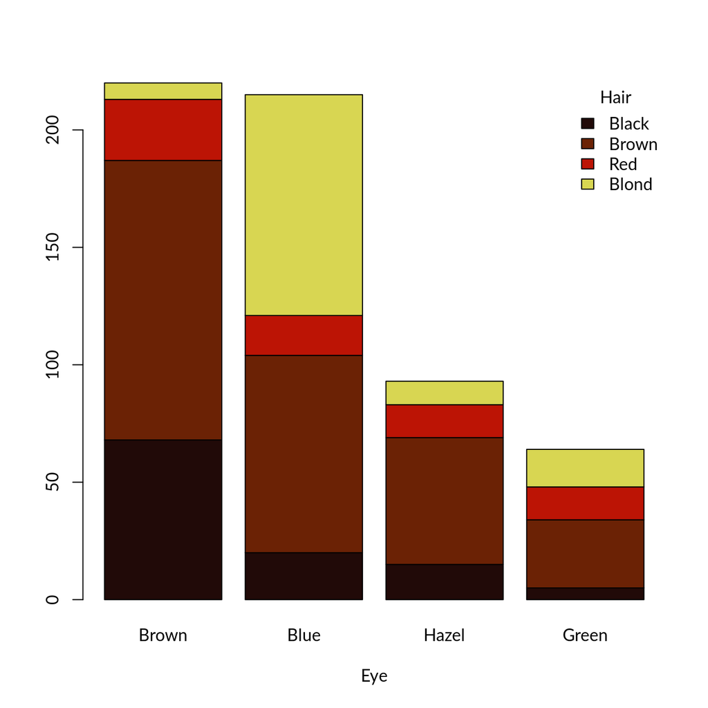

```r
# Barras empilhadas.
barplot(a,
        xlab = "Eye",
        col = cols[rownames(a)])
legend("topright",
       title = "Hair",
       legend = rownames(a),
       fill = cols[rownames(a)],
       bty = "n")
```

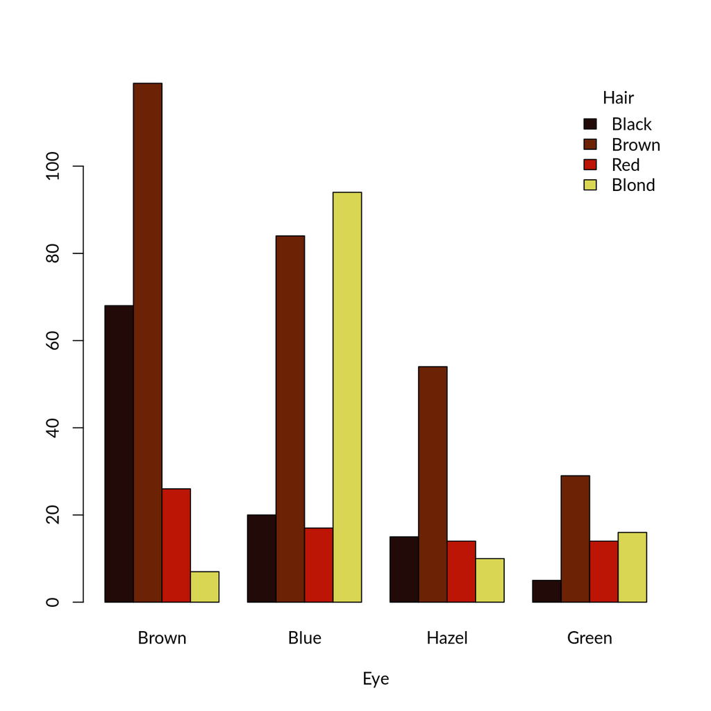

```r
# Barras lado a lado.
barplot(a,
        xlab = "Eye",
        beside = TRUE,
        col = cols[rownames(a)])
legend("topright",
       title = "Hair",
       legend = rownames(a),
       fill = cols[rownames(a)],
       bty = "n")
```

```r
# Visite estes sites para pegar cores.
# browseURL("http://www.w3schools.com/html/html_colors.asp")
# browseURL("http://html-color-codes.info/")
```

# 5 Gráficos para uma variável contínua

Para representar a distribuição de frequência de variáveis contínuas tem-se mais opções. A mais simples delas, o histograma, consiste em discretizar os dados agrupando as observações em classes. A frequência das classes é exibida contra as classes.

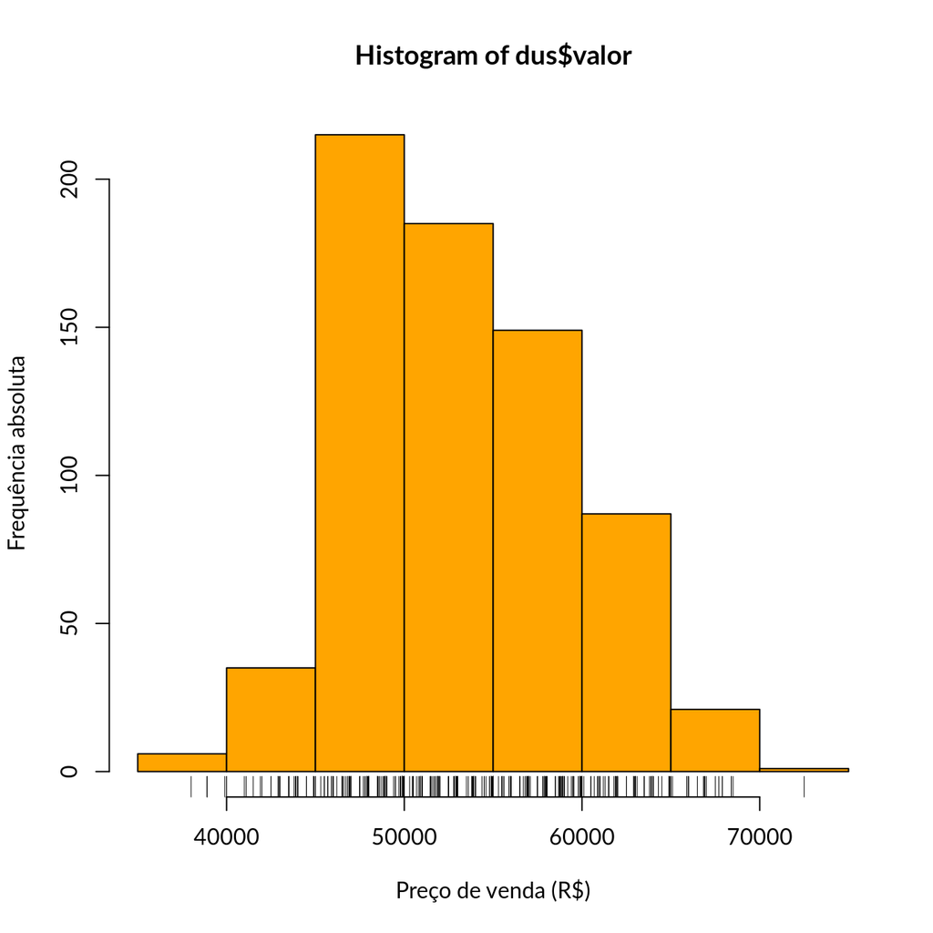

```r
#-----------------------------------------------------------------------
# Histograma.

# Gráfico básico.
# hist(dus$valor)

hist(dus$valor,
     xlab = "Preço de venda (R$)",
     ylab = "Frequência absoluta",
     col = "orange")
rug(dus$valor)
```

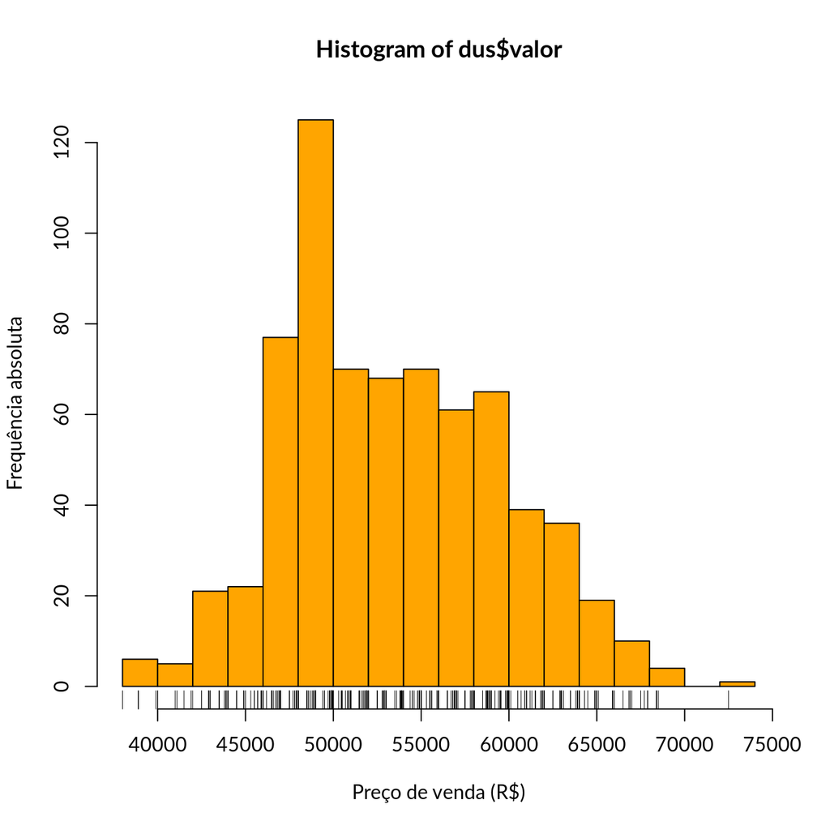

```r
# Se breaks é um escalar então entende-se que é uma *sugestão* para o
# número de clases.
hist(dus$valor,
     breaks = 15,
     xlab = "Preço de venda (R$)",
     ylab = "Frequência absoluta",
     col = "orange")
rug(dus$valor)
```

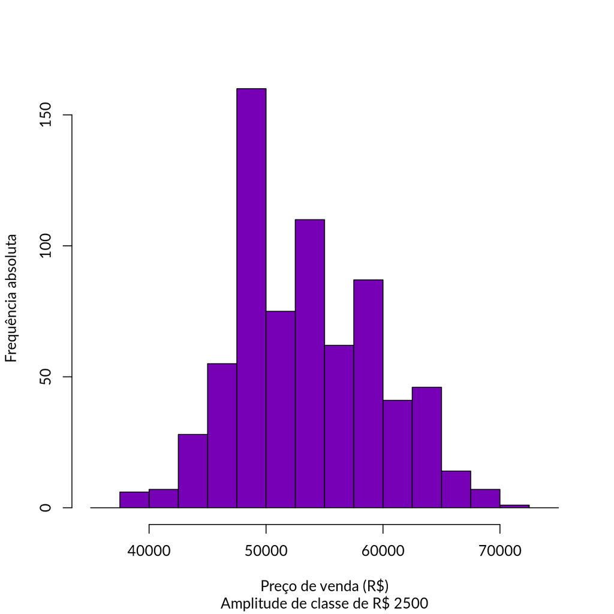

```r
# Se breaks é um vetor então entende-se que são os limites para
# classificação dos valores.
hist(dus$valor,
     breaks = seq(35000, 75000, by = 2500),
     xlab = "Preço de venda (R$)",
     ylab = "Frequência absoluta",
     col = "#7700B7",
     sub = "Amplitude de classe de R$ 2500",
     main = NULL)
```

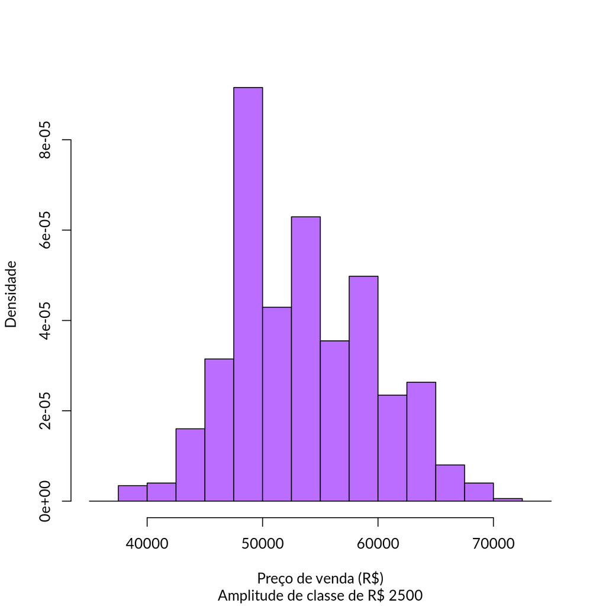

```r
# Gráfico onde a altura é a densidade e não a frequência.
hist(dus$valor,
     prob = TRUE,
     breaks = seq(35000, 75000, by = 2500),
     xlab = "Preço de venda (R$)",
     ylab = "Densidade",
     col = "#ba6dff",
     sub = "Amplitude de classe de R$ 2500",
     main = NULL)
```

O histograma pode representar duas medidas diferentes, porem relacionadas, de frequência. Como argumento `prob = FALSE`, a altura da barra é o número de registros em cada classe. Com `prob = TRUE`, o produto da altura (densidade) pela largura (amplitude de classe) de cada barra corresponde a frequência relativa. A soma das frequências relativas é 1 e, portanto, a área do gráfico coberta pelas barras do histograma é unitária.

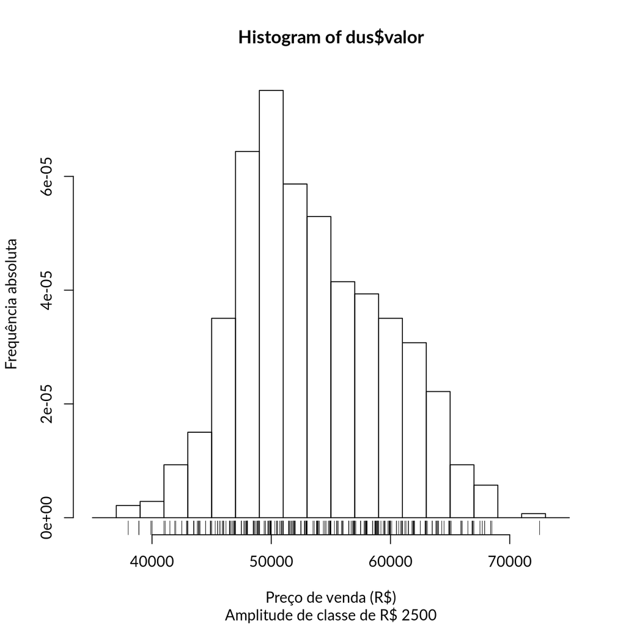

```r
#-----------------------------------------------------------------------
# Anotações sobre um histograma.

# Com domínio do R se pode fazer gráficos espetaculares, como por
# exemplo esses com variação da tonalidade ou destaque da classe modal.

ht <- hist(dus$valor,
           prob = TRUE,
           breaks = seq(35000, 75000, 2000),
           xlab = "Preço de venda (R$)",
           ylab = "Frequência absoluta",
           sub = "Amplitude de classe de R$ 2500")
rug(dus$valor) # Faz risquinhos no eixo x.
```

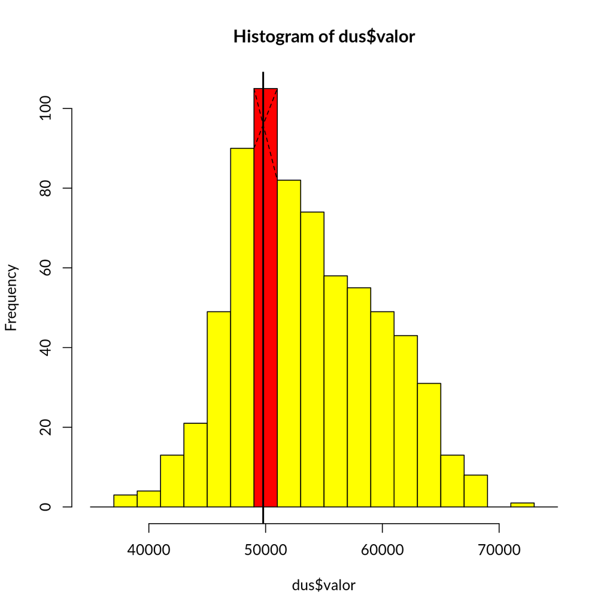

```r
# Destacar a barra da classe modal usando outra cor.
wm <- which.max(ht$counts)
cols <- rep("yellow", length(ht$counts))
cols[wm] <- "red"
cols
#  [1] "yellow" "yellow" "yellow" "yellow" "yellow" "yellow" "yellow"
#  [8] "red"    "yellow" "yellow" "yellow" "yellow" "yellow" "yellow"
# [15] "yellow" "yellow" "yellow" "yellow" "yellow" "yellow"

plot(ht, col = cols)

# Traçar os segmentos que indicam o valor interpolado para a moda.
ycoor <- with(ht, counts[wm + 0:1])
xcoor <- with(ht, breaks[wm + 0:1])
segments(xcoor[1], ycoor[1], xcoor[2], ycoor[2], lty = 2)

ycoor <- with(ht, counts[wm - 1:0])
xcoor <- with(ht, breaks[wm + 0:1])
segments(xcoor[1], ycoor[1], xcoor[2], ycoor[2], lty = 2)

# Por semelhança de triangulos a moda obtida é:
ac <- with(ht, diff(breaks[1:2]))
d <- with(ht, abs(diff(counts[wm + (-1:1)])))
xmoda <- with(ht, breaks[wm] + (ac * d[1])/sum(d))
xmoda
# [1] 49789.47

abline(v = xmoda, lwd = 2)
```

É possível fazer gráficos personalizados com o domínios dos recursos básicos de plotagem do R. O código acima usa a função de alto nível `hist()` para produzir o histograma. Quando atribuida a um objeto, todos os elementos do histograma ficam salvos para permitir pós processamento (limites e cento das classes, frequência absoluta e relativa, etc). Funções de baixo nível (`abline()`, `segments()`) são chamadas para adicionar elementos aos gráficos.

Os dois gráficos abaixo fazem uso das funções de baixo para ilustrar o potencial do R para confecção de gráficos. No entanto, tais gráficos podem não ter muita utilidade prática.

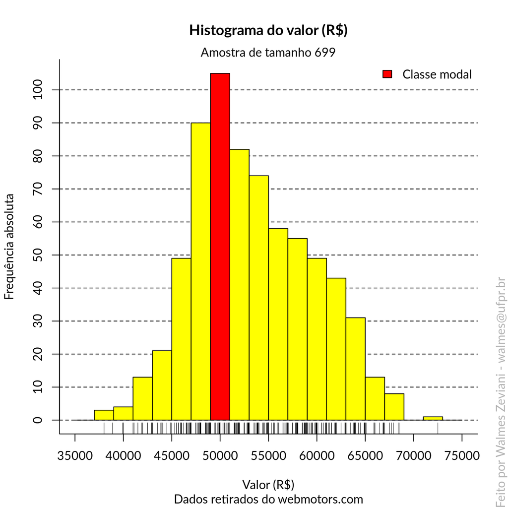

```r
#--------------------------------------------
# Destaque para a classe modal.

plot(ht,
     col = NULL,
     lty = 0,
     ann = FALSE,
     axes = FALSE)
abline(h = seq(0, 100, by = 10), lty = 2)
plot(ht,
     col = cols,
     ann = FALSE,
     axes = FALSE,
     add = TRUE)
rug(dus$valor)
axis(side = 1, at = seq(35000, 75000, 5000))
axis(side = 2, at = seq(0, 100, by = 10))
box(bty = "L")
title(main = "Histograma do valor (R$)",
      sub = "Dados retirados do webmotors.com",
      xlab = "Valor (R$)",
      ylab = "Frequência absoluta")
mtext(side = 3, line = 0,
      text = paste("Amostra de tamanho", length(dus$valor)))
mtext(side = 4,
      line = -1,
      col = "gray70",
      outer = TRUE,
      adj = 0,
      text = "Feito por Walmes Zeviani - walmes@ufpr.br")
legend("topright",
       fill = "red",
       legend = "Classe modal",
       bty = "n")
```

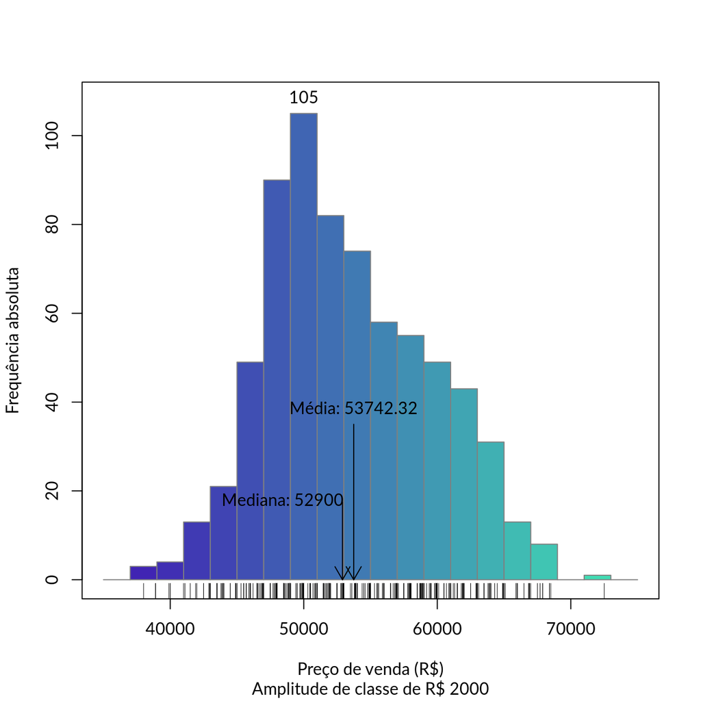

```r
#--------------------------------------------

# Outra variação de um histograma.
ht <- hist(dus$valor, seq(35000, 75000, 2000), plot = FALSE)
nc <- length(ht$mids)             # Número de classes.
ac <- diff(ht$breaks[1:2])        # Amplitude de classe.
ma <- mean(dus$valor)             # Média da amostra.
md <- median(dus$valor)           # Mediana da amostra.
qts <- fivenum(dus$valor)[c(2,4)] # 1Q e 3Q da amostra.
modal <- which.max(ht$counts)     # Classe modal.
modal <- list(x = ht$mids[modal], y = ht$counts[modal])
colseq <- rgb(red = 0.25,
              blue = 0.7,
              green = seq(0.1, 0.9, length.out = nc))

plot(ht,
     col = colseq,
     ylim = c(0, modal$y + strheight("1")),
     xlab = "Preço de venda (R$)",
     ylab = "Frequência absoluta",
     sub = paste("Amplitude de classe de R$", ac),
     main = NULL,
     border = "gray50")
rug(dus$valor)
text(x = modal$x, y = modal$y, labels = modal$y, pos = 3)
arrows(ma, 0, ma, modal$y/3, code = 1, length = 0.15)
text(ma, modal$y/3, labels = paste("Média:", round(ma,2)), pos = 3)
arrows(md, 0, md, modal$y/6, code = 1, length = 0.15)
text(ma, modal$y/6, labels = paste("Mediana:", round(md,1)),
     pos = ifelse(md<ma, 2, 4))
box()
```

Responda: o que de informação adicional foi acrescentado com as barras mudando de cor? Nada! A variação das cores está se sobrepondo a informação de posição no eixo horizontal. Ou seja, são dois elementos estéticos (posição e preenchimento) mapeando a mesma informação. Uma boa prática na confecção de gráficos e evitar redundância. Pode até ser que o leitor seja atraído pelo visual pouco ortodoxo do gráfico mas há um desperdício de carga cognitiva para processamento dessa informação visual acessória ou meramente estética.

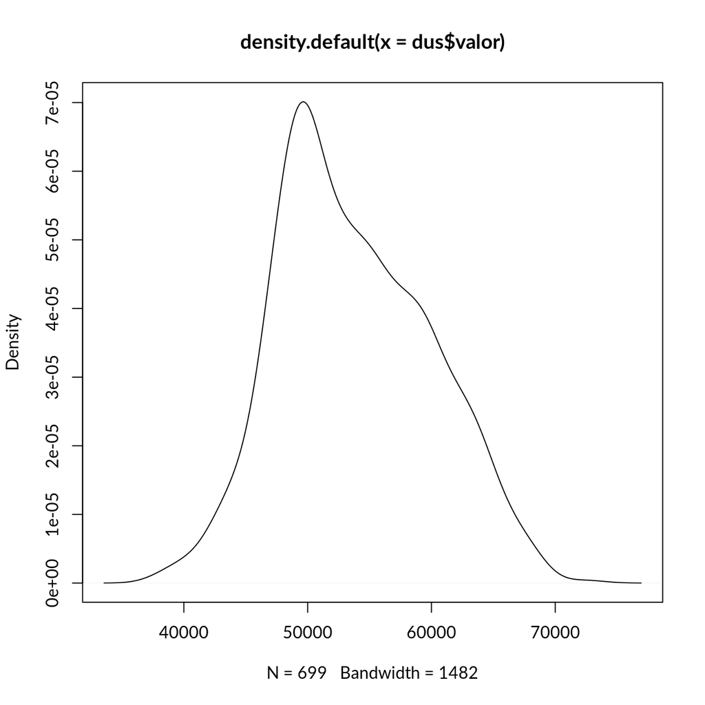

```r
#-----------------------------------------------------------------------
# Gráficos de densidade.

den <- density(dus$valor)
plot(den)
```

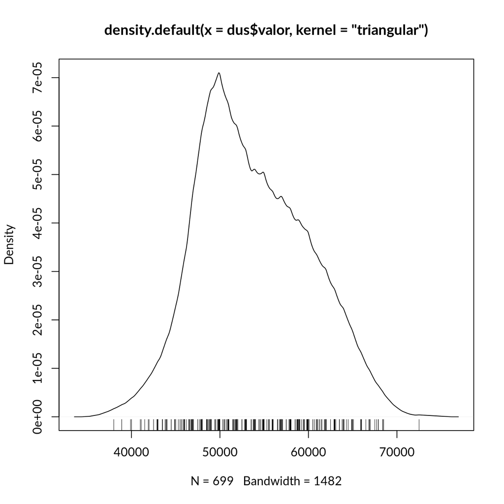

```r
den
#
# Call:
#   density.default(x = dus$valor)
#
# Data: dus$valor (699 obs.);   Bandwidth 'bw' = 1482
#
#        x               y
#  Min.   :33555   Min.   :4.340e-09
#  1st Qu.:44402   1st Qu.:1.390e-06
#  Median :55250   Median :1.492e-05
#  Mean   :55250   Mean   :2.302e-05
#  3rd Qu.:66098   3rd Qu.:4.304e-05
#  Max.   :76945   Max.   :7.011e-05

# Tipos de função kernel.
formals("density.default")$kernel
# c("gaussian", "epanechnikov", "rectangular", "triangular", "biweight",
#     "cosine", "optcosine")

den <- density(dus$valor,
               kernel = "triangular")
plot(den)
rug(dus$valor)
```

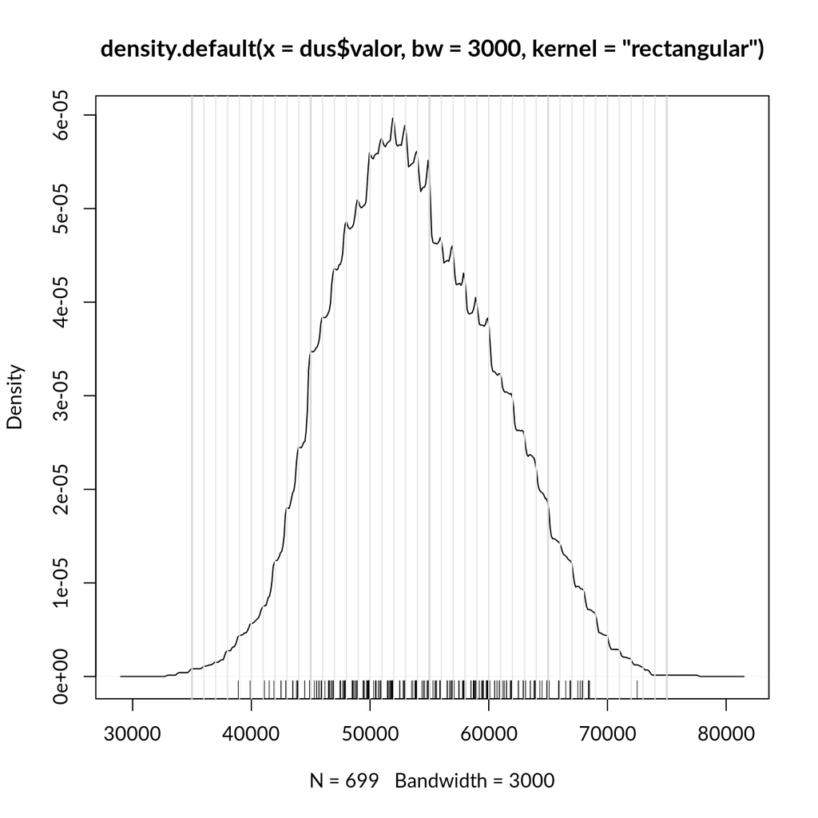

```r
# Controle da largura de banda.
den <- density(dus$valor,
               kernel = "rectangular",
               bw = 3000)
plot(den)
rug(dus$valor)
abline(v = seq(35000, 75000, 5000), col = "gray50")
abline(v = seq(35000, 75000, 1000), col = "gray90")
```

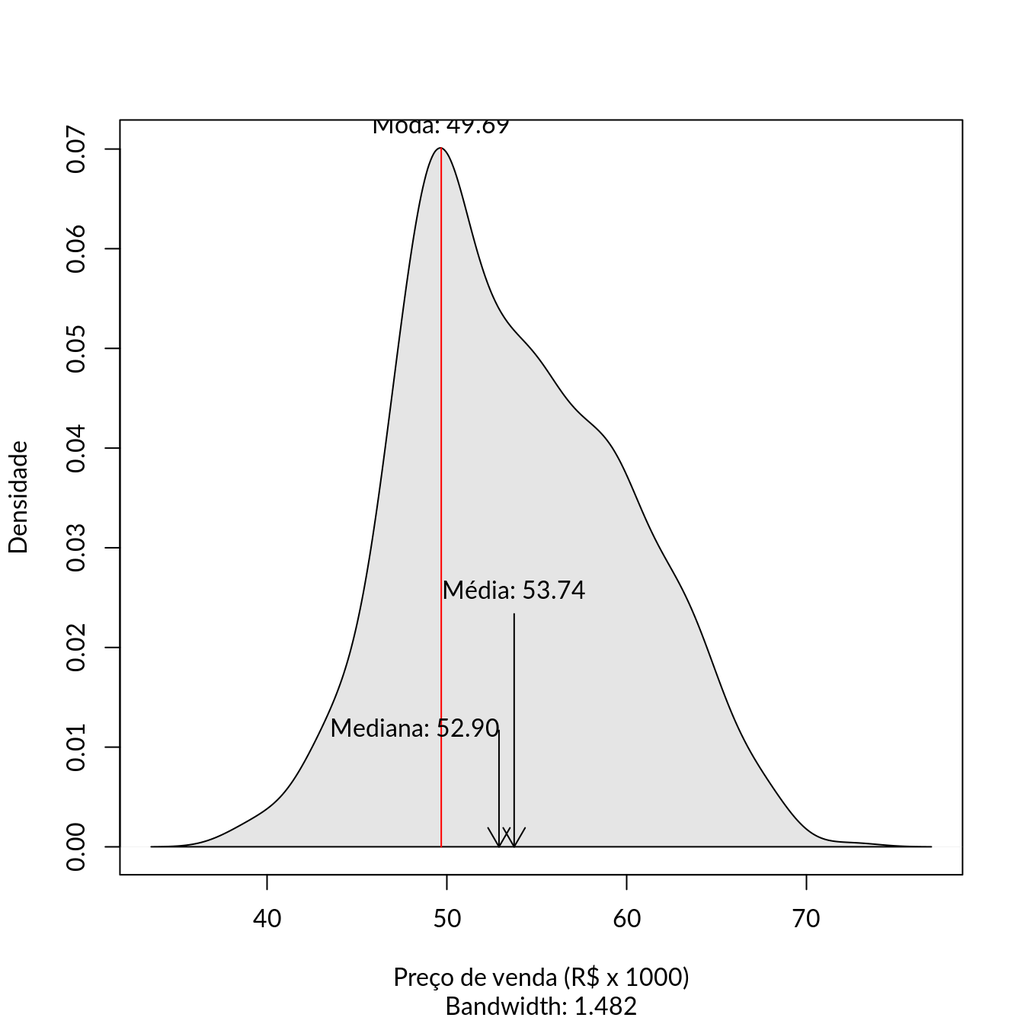

```r
# Realce da classe modal.
den <- density(dus$valor/1000)
str(den)
# List of 7
#  $ x        : num [1:512] 33.6 33.6 33.7 33.8 33.9 ...
#  $ y        : num [1:512] 5.62e-06 6.73e-06 8.03e-06 9.52e-06 1.13e-05 ...
#  $ bw       : num 1.48
#  $ n        : int 699
#  $ call     : language density.default(x = dus$valor/1000)
#  $ data.name: chr "dus$valor/1000"
#  $ has.na   : logi FALSE
#  - attr(*, "class")= chr "density"

x <- eval(parse(text = den$data.name))
ma <- mean(x)             # Média da amostra.
md <- median(x)           # Mediana da amostra.

modal <- which.max(den$y)
modal <- list(x = den$x[modal], y = den$y[modal])

plot(den,
     type = "n",
     xlab = "Preço de venda (R$ x 1000)",
     ylab = "Densidade",
     ylim = c(0, modal$y + strheight("1")),
     main = "",
     sub = paste("Bandwidth:", round(den$bw,3)))
with(den, polygon(x, y, col = "gray90"))
with(modal, {
    segments(x, 0, x, y, col = 2)
    text(x, y, labels = sprintf("Moda: %0.2f", x), pos = 3)
})
arrows(ma, 0, ma, modal$y/3, code = 1, length = 0.15)
text(ma, modal$y/3, labels = sprintf("Média: %0.2f", ma), pos = 3)
arrows(md, 0, md, modal$y/6, code = 1, length = 0.15)
text(ma, modal$y/6, labels = sprintf("Mediana: %0.2f", md),
     pos = ifelse(md<ma, 2, 4))
rug(dus$valor)
# Warning in rug(dus$valor): some values will be clipped
```

O gráfico de densidade empírica kernel é o sucessor ou evolução do histograma. Esse gráfico calcula a densidade em um ponto $x$ no domínio da variável por meio de uma função kernel que é, de forma simples, uma função de ponderação, e o resultado e uma soma de frequências ponderada pela distância. Existem 7 funções kernel disponíveis. Visite essa aplicação Shiny para compreender visualmente como funciona a densidade kernel: http://shiny.leg.ufpr.br/walmes/density/.

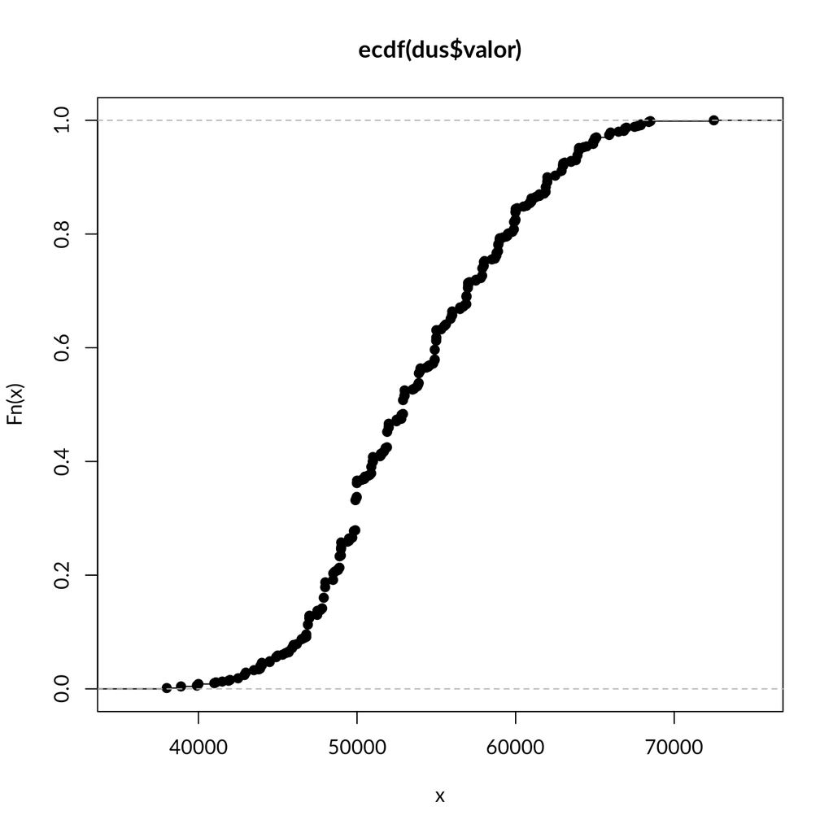

```r
#-----------------------------------------------------------------------
# Gráfico de frequência acumulada empírica.

y <- ecdf(dus$valor)
plot(y)
```